# 10-Results

Laura H Spencer

3/23/2020

In this notebook I will compile results that I will include in the manuscript.

### Description of general methylation patterns

```r
methdata.summary[methdata.summary$feature=="all", "all5x"] #all characterized loci
```

```
## [1] 2030624
```

```r
methdata.summary[methdata.summary$feature=="all", "methylated"] #all methylated loci
```

```
## [1] 1839241
```

```r
percent(methdata.summary[methdata.summary$feature=="all", "methylated"]/methdata.summary[methdata.summary$feature=="all", "all5x"], accuracy=0.1)
```

```
## [1] "90.6%"
```

```r
# Where methylated loci are located
methdata.summary[methdata.summary$feature=="gene", "methylated"] # No. in genes
```

```
## [1] 633991
```

```r
percent(methdata.summary[methdata.summary$feature=="gene", "methylated"]/methdata.summary[methdata.summary$feature=="all", "methylated"], accuracy=0.1) #% in genes
```

```
## [1] "34.5%"
```

```r
percent(methdata.summary[methdata.summary$feature=="exon", "methylated"]/methdata.summary[methdata.summary$feature=="all", "methylated"], accuracy=0.1) #% in exons
```

```
## [1] "14.7%"
```

```r
percent(methdata.summary[methdata.summary$feature=="intron", "methylated"]/methdata.summary[methdata.summary$feature=="all", "methylated"], accuracy=0.1) #% in introns
```

```
## [1] "19.8%"
```

```r
methdata.summary[methdata.summary$feature=="2kbflank-up", "methylated"] # No. upstream genes
```

```
## [1] 85425
```

```r
percent(methdata.summary[methdata.summary$feature=="2kbflank-up", "methylated"]/methdata.summary[methdata.summary$feature=="all", "methylated"], accuracy=0.1) # % upstream genes
```

```
## [1] "4.6%"
```

```r
methdata.summary[methdata.summary$feature=="2kbflank-down", "methylated"] # No. downstream genes
```

```
## [1] 85795
```

```r
percent(methdata.summary[methdata.summary$feature=="2kbflank-down", "methylated"]/methdata.summary[methdata.summary$feature=="all", "methylated"], accuracy=0.1) # % downtream genes
```

```
## [1] "4.7%"
```

```r
methdata.summary[methdata.summary$feature=="TE", "methylated"] # No. transposable elements
```

```
## [1] 254363
```

```r
percent(methdata.summary[methdata.summary$feature=="TE", "methylated"]/methdata.summary[methdata.summary$feature=="all", "methylated"], accuracy=0.1) # % in transposable elements
```

```
## [1] "13.8%"
```

```r
methdata.summary[methdata.summary$feature=="ASV", "methylated"] # No. overlap w/ ASV
```

```
## [1] 1386721
```

```r
methdata.summary[methdata.summary$feature=="unknown", "methylated"] # No. intergenic
```

```
## [1] 593224
```

```r
percent(methdata.summary[methdata.summary$feature=="unknown", "methylated"]/methdata.summary[methdata.summary$feature=="all", "methylated"], accuracy=0.1) # % intergenic
```

```
## [1] "32.3%"
```

Of the 2,030,624 characterized loci, 1,839,241 were methylated (90.6%). Of the methylated loci, 633,991 were within known genes (34.5%, 14.7% in exons, 19.8% in introns), 85,425 and 85,795 were 2kb upstream and downstream of known genes, respectively (4.6%) and 4.7%), 254,363 were within transposable elements (13.8%), and there were 1,386,721 instances of overlap between methylated loci and alternative splice variants. 593,224 of the methylated loci were not associated with known regions (i.e. intergenic beyond 2kb gene flanking regions, 32.3%).

### Description of methylation data used for DML and SAL analysis

In total, 33,738 loci were analyzed. 1,836,662 loci were discarded because they did not pass the filtering requirements of 10-100 reads across 7 of the 9 samples per population.

Overall, loci were highly methylated. Across all samples, loci were on average 89.6% methylated.

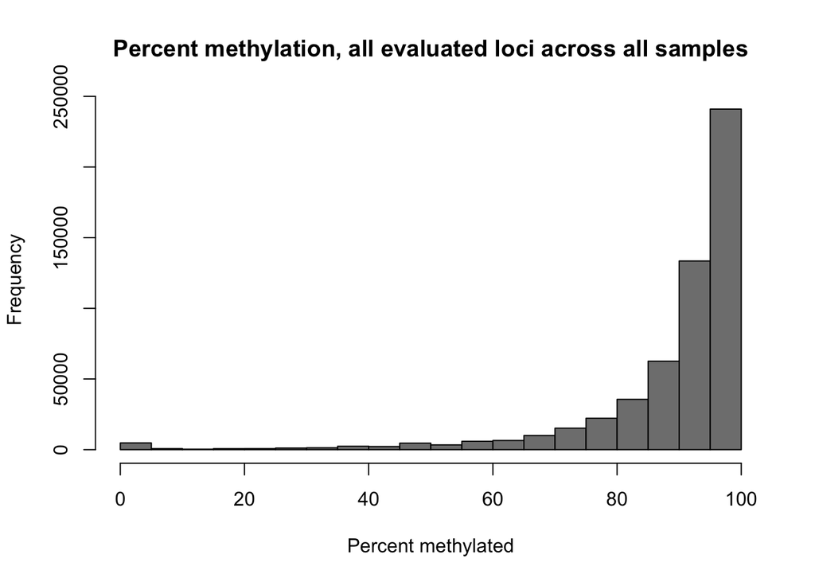

Of all 33,738 evaluated loci, 18,688 were located within known genes (55.4%), 15,943 of which were located within exons (47.3%), 2,385 flanked known genes (within 2kb, 7.1%), 1,588 were found within transposable elements (4.7%), and 4,156 were not found in any known feature (12.3%).

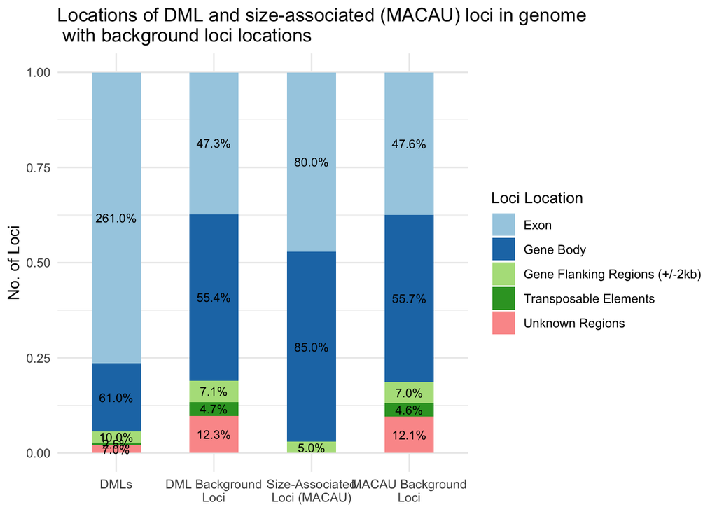

### Differential methylation

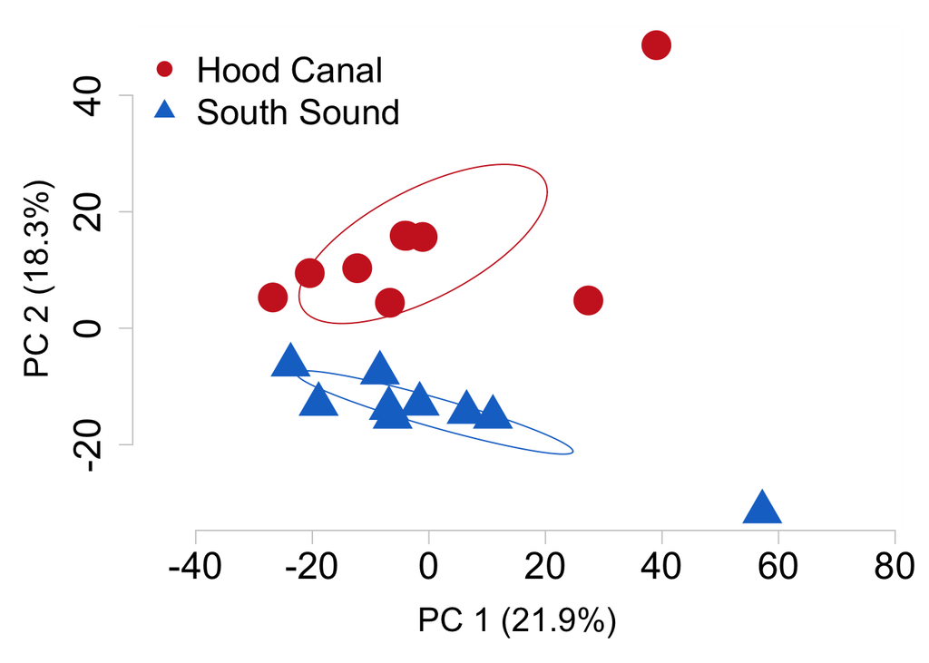

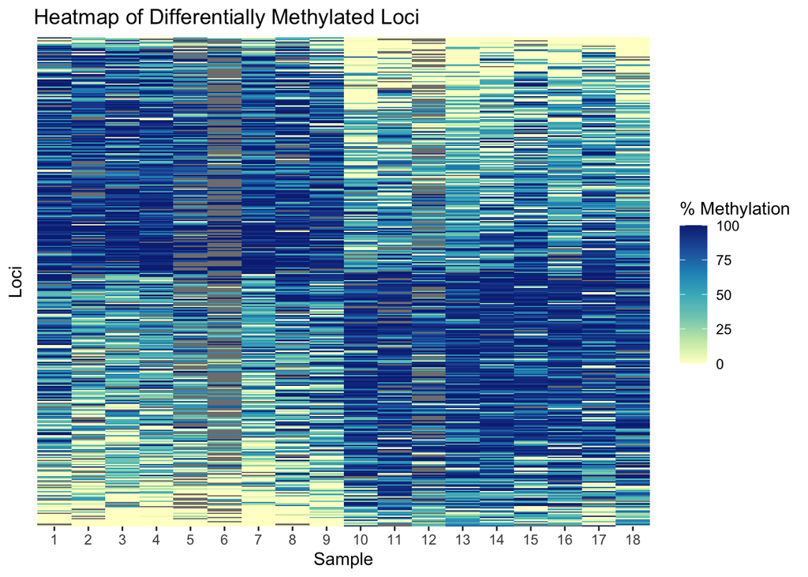

#### Enriched Biological functions, DMLs

The GO MWU analysis did not identify any enriched biological functions. Enrichment analysis using the DAVID tool identified 7 enriched biological processes (Table 1).

#### Table 1: Enriched biological functions of genes that contain differentially methylated loci

| GO Term | Biological Process | PValue | Fold Enrichment | Count |
| --- | --- | --- | --- | --- |
| GO:0006513 | protein monoubiquitination | 0.010 | 8.0 | 4 |
| GO:0006284 | base-excision repair | 0.015 | 7.1 | 4 |
| GO:0048565 | digestive tract development | 0.033 | 9.6 | 3 |
| GO:0006974 | cellular response to DNA damage stimulus | 0.059 | 2.4 | 7 |
| GO:0042127 | regulation of cell proliferation | 0.071 | 4.0 | 4 |
| GO:0000902 | cell morphogenesis | 0.083 | 6.0 | 3 |
| GO:0055085 | transmembrane transport | 0.099 | 2.8 | 5 |

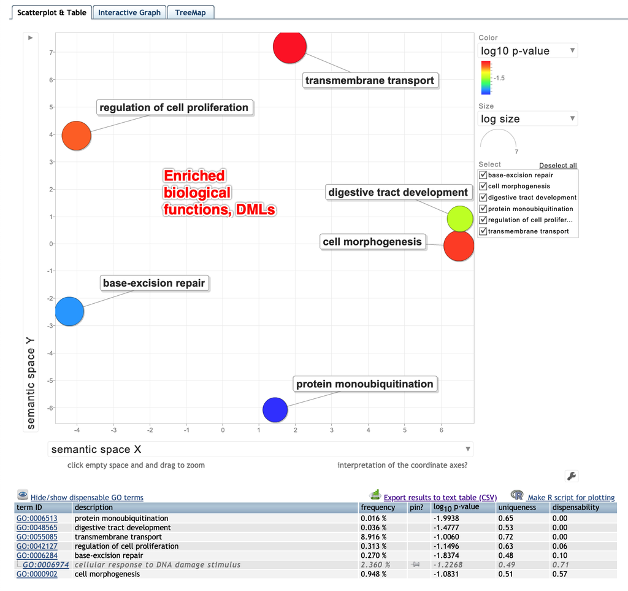

DML_REVIGO_BP.png

#### Location of loci with high and low Pst values

- What constitutes high and low?

### Methylated gene regions

Of the 1,393 gene regions (genes +/- 2kb) assessed, 279 were differentially methylated. Of these, there were 96 differentially methylated gene regions that contained DMLs (determined via a separate analysis).

#### Enriched DMG functions

**Biological Processes: regulation of protein kinase activity (P-Value=0.072)**

| GCN1, eIF2 alpha kinase activator homolog(GCN1) | Q92616 | Homo sapiens |
| --- | --- | --- |
| kinase D-interacting substrate 220kDa(KIDINS220) | Q9ULH0 | Homo sapiens |
| titin(TTN) | Q8WZ42 | Homo sapiens |
| titin(Ttn) | A2ASS6 | Mus musculus |

**Molecular Functions: ligase activity (P-Value=0.087)**

| HECT domain containing 1(Hectd1) | Q69ZR2 | Mus musculus |
| --- | --- | --- |
| HECT, UBA and WWE domain containing 1, E3 ubiquitin protein ligase(HUWE1) | Q7Z6Z7 | Homo sapiens |
| PYruvate Carboxylase(pyc-1) | O17732 | Caenorhabditis elegans |
| nuclear transcription factor, X-box binding 1(NFX1) | Q12986 | Homo sapiens |
| ring finger protein 103(Rnf103) | Q9R1W3 | Mus musculus |
| ring finger protein 168(rnf168) | Q7T308 | Danio rerio |
| ring finger protein 38(RNF38) | Q9H0F5 | Homo sapiens |
| succinate-CoA ligase, alpha subunit(Suclg1) | P13086 | Rattus norvegicus |
| tripartite motif containing 2(TRIM2) | A4IF63 | Bos taurus |
| tripartite motif-containing 2(Trim2) | D3ZQG6 | Rattus norvegicus |
| ubiquitin protein ligase E3 component n-recognin 5(Ubr5) | Q80TP3 | Mus musculus |

**Molecular Functions: DNA binding (P-Value=0.091)**

| AE binding protein 2(aebp2) | Q7SXV2 | Danio rerio |
| --- | --- | --- |
| AT-hook containing transcription factor 1 L homeolog(ahctf1.L) | Q5U249 | Xenopus laevis |
| AT-rich interaction domain 2(ARID2) | Q68CP9 | Homo sapiens |
| E1A binding protein p400(Ep400) | Q8CHI8 | Mus musculus |
| GLIS family zinc finger 3(Glis3) | Q6XP49 | Mus musculus |
| HECT, UBA and WWE domain containing 1, E3 ubiquitin protein ligase(HUWE1) | Q7Z6Z7 | Homo sapiens |
| JRK-like(JRKL) | Q9Y4A0 | Homo sapiens |
| Nuclear Hormone Receptor family(nhr-41) | Q9N4B8 | Caenorhabditis elegans |
| PR domain containing 1, with ZNF domain(Prdm1) | Q60636 | Mus musculus |
| PYruvate Carboxylase(pyc-1) | O17732 | Caenorhabditis elegans |
| Putative histone H1.6(hil-6) | O16277 | Caenorhabditis elegans |
| RAB guanine nucleotide exchange factor (GEF) 1(Rabgef1) | Q9JM13 | Mus musculus |
| SET domain, bifurcated 1 L homeolog(setdb1.L) | Q6INA9 | Xenopus laevis |
| Zn finger homeodomain 1(zfh1) | P28166 | Drosophila melanogaster |
| chromodomain helicase DNA binding protein 8(chd8) | B0R0I6 | Danio rerio |
| conserved Plasmodium protein, unknown function(PF14_0175) | Q8ILR9 | Plasmodium falciparum 3D7 |
| ligase I, DNA, ATP-dependent S homeolog(lig1.S) | P51892 | Xenopus laevis |
| methyl-CpG binding domain protein 6(Mbd6) | Q3TY92 | Mus musculus |
| orphan steroid hormone receptor 2(shr2) | Q26622 | Strongylocentrotus purpuratus |
| regulatory factor X7(RFX7) | Q2KHR2 | Homo sapiens |
| transcription factor B1, mitochondrial(tfb1m) | Q28HM1 | Xenopus tropicalis |
| zinc finger and BTB domain containing 24(zbtb24) | Q52KB5 | Danio rerio |
| zinc finger protein 236(ZNF236) | Q9UL36 | Homo sapiens |
| zinc finger protein 471(ZNF471) | Q9BX82 | Homo sapiens |
| zinc finger protein 525(ZNF525) | Q8N782 | Homo sapiens |
| zinc finger protein interacting with K protein 1(Zik1) | Q80YP6 | Mus musculus |
| zinc finger, MYM-type 4(Zmym4) | A2A791 | Mus musculus |

**Cellular Compoent: midbody (P-value=0.069)**

| CTD phosphatase subunit 1(CTDP1) | Q9Y5B0 | Homo sapiens |
| --- | --- | --- |
| phosphatidylinositol transfer protein, membrane-associated 1(Pitpnm1) | Q5U2N3 | Rattus norvegicus |
| septin 7(SEPT7) | Q5R1W1 | Pan troglodytes |
| supervillin(SVIL) | O95425 | Homo sapiens |
| supervillin(SVIL) | O46385 | Bos taurus |
| tetratricopeptide repeat domain 28(TTC28) | Q96AY4 | Homo sapiens |

#### Relationship between Pst values and DMG P-adjusted values

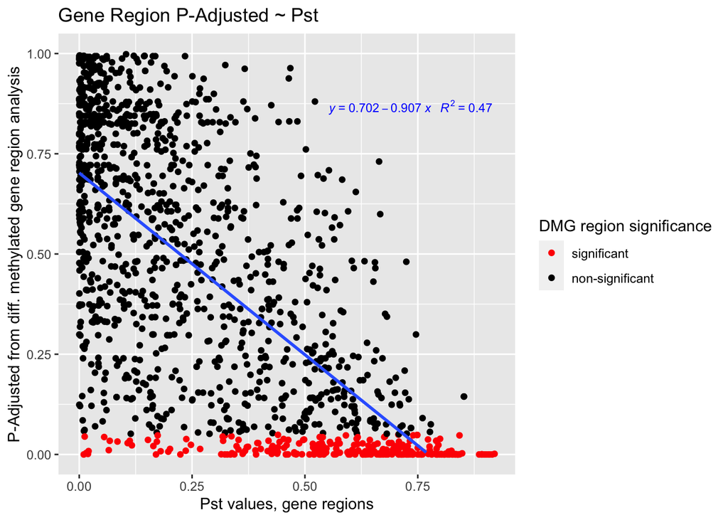

#### Other ideas for DMGs

- DMGs - what are the Fst values?
- Which genes have low Pst values but are differentially methylated?

### Methylated loci associated with size (MACAU)

To examine whether methylation plays a role in population-specific growth traits, we modeled methylation level for each loci using MACAU, while controlling for relatedness. Of the 33,284 loci assessed, 20 loci were associated with oyster size (shell length, whole wet weight as covariate). Of the 20 loci, 17 were located within known gene bodies (16 in exons), and 1 locus flanked genes (+/- 2kb). The number of size-associated loci that were also differentially methylated among populations was 1, which indicates that the associations were not primarily due to population structure.

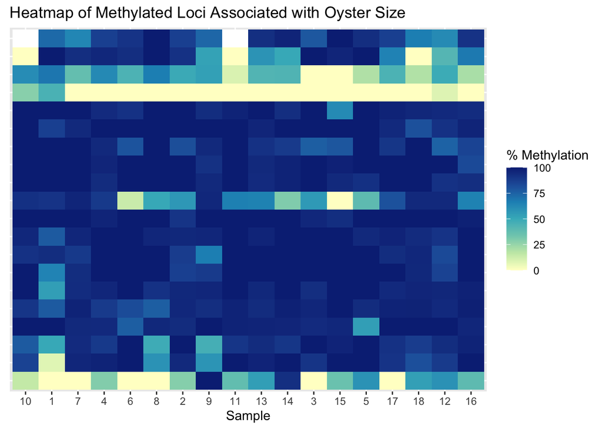

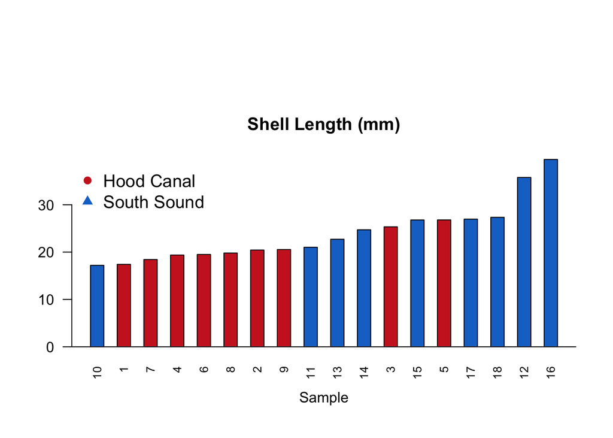

#### Table 2: Enriched biological functions of genes that contain loci which are associated with oyster size

| GO Term | Biologica Function | PValue | Fold Enrichment | Count |
| --- | --- | --- | --- | --- |
| GO:0006607 | NLS-bearing protein import into nucleus | 5.85E-04 | 68.4 | 3 |
| GO:0006610 | ribosomal protein import into nucleus | 0.02238718 | 79.8 | 2 |
| GO:0000059 | protein import into nucleus, docking | 0.02791389 | 63.84 | 2 |
| GO:0000060 | protein import into nucleus, translocation | 0.04432776 | 39.9 | 2 |

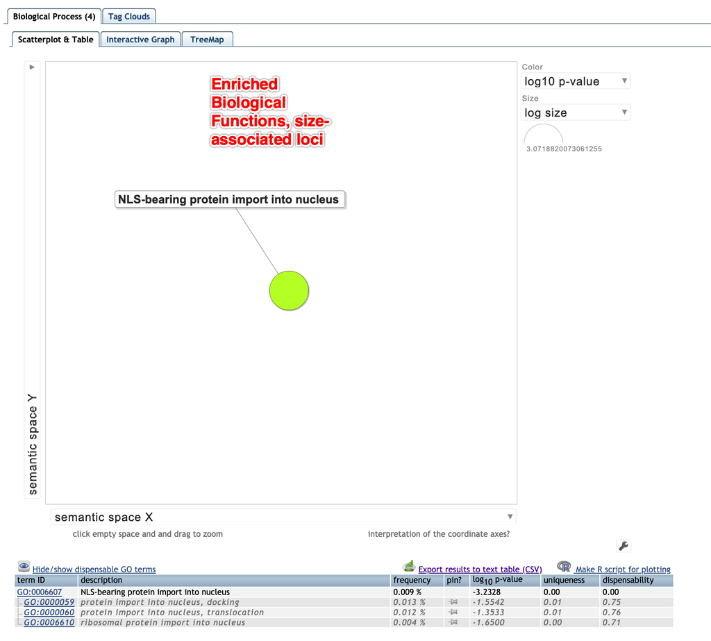

MACAU_REVIGO_BP.png

### Methylation and genetic data integration

Across all genes that contain methylation data (n=3754), mean Pst was 29.4% +/- 24.7% (SD).

```r
nrow(genes_2kbslop_Pst)
```

```
## [1] 3754
```

```r
percent(mean(genes_2kbslop_Pst$Pst_Values), accuracy = .1)
```

```
## [1] "29.4%"
```

```r
percent(sd(genes_2kbslop_Pst$Pst_Values), accuracy = .1)
```

```
## [1] "24.7%"
```